# D21034 - Recommender system

# 5.User-User Collaborative filtering

This filter makes recommendation based on users interaction with the movies in the past. The assumption is that similar users likes similar movies

- To find similar users based on their ratings for the similar movies they watched
- Identify the movies rated high by similar users
- Find the mean-centric cosine similarity for those users movie ratings
- Find similarities based on these scores

```python
movies = pd.read_csv(r"C:\Users\Admin\Documents\Praxis\Term-2\AML\movies.csv")
ratings = pd.read_csv(r"C:\Users\Admin\Documents\Praxis\Term-2\AML\ratings.csv")
```

```python
movies.head()
```

|  | movieId | title | genres |
| --- | --- | --- | --- |
| 0 | 1 | Toy Story (1995) | Adventure\|Animation\|Children\|Comedy\|Fantasy |
| 1 | 2 | Jumanji (1995) | Adventure\|Children\|Fantasy |
| 2 | 3 | Grumpier Old Men (1995) | Comedy\|Romance |
| 3 | 4 | Waiting to Exhale (1995) | Comedy\|Drama\|Romance |
| 4 | 5 | Father of the Bride Part II (1995) | Comedy |

```python
#Convert the timestamp column to datetime
ratings['timestamp'] = pd.to_datetime(ratings['timestamp'], unit='s')
```

```python
ratings.head()
```

|  | userId | movieId | rating | timestamp |
| --- | --- | --- | --- | --- |
| 0 | 1 | 1 | 4.0 | 2000-07-30 18:45:03 |
| 1 | 1 | 3 | 4.0 | 2000-07-30 18:20:47 |
| 2 | 1 | 6 | 4.0 | 2000-07-30 18:37:04 |
| 3 | 1 | 47 | 5.0 | 2000-07-30 19:03:35 |
| 4 | 1 | 50 | 5.0 | 2000-07-30 18:48:51 |

```python
print( "The ratings dataset has" ,ratings['userId'].nunique(), 'unique users')
print( "The ratings dataset has" ,ratings['movieId'].nunique(), 'unique movies')
print( "The ratings dataset has" ,ratings['rating'].nunique(), 'unique ratings')
```

```
The ratings dataset has 610 unique users
The ratings dataset has 9724 unique movies
The ratings dataset has 10 unique ratings
```

```python
print('The unique ratings given by the users are',sorted(ratings['rating'].unique()))
```

```
The unique ratings given by the users are [0.5, 1.0, 1.5, 2.0, 2.5, 3.0, 3.5, 4.0, 4.5, 5.0]
```

## Data Preprocessing

```python
df_ratings = pd.merge(ratings, movies, on='movieId' , how='inner')
```

```python
df_ratings.head()
```

|  | userId | movieId | rating | timestamp | title | genres |
| --- | --- | --- | --- | --- | --- | --- |
| 0 | 1 | 1 | 4.0 | 2000-07-30 18:45:03 | Toy Story (1995) | Adventure\|Animation\|Children\|Comedy\|Fantasy |
| 1 | 5 | 1 | 4.0 | 1996-11-08 06:36:02 | Toy Story (1995) | Adventure\|Animation\|Children\|Comedy\|Fantasy |
| 2 | 7 | 1 | 4.5 | 2005-01-25 06:52:26 | Toy Story (1995) | Adventure\|Animation\|Children\|Comedy\|Fantasy |
| 3 | 15 | 1 | 2.5 | 2017-11-13 12:59:30 | Toy Story (1995) | Adventure\|Animation\|Children\|Comedy\|Fantasy |
| 4 | 17 | 1 | 4.5 | 2011-05-18 05:28:03 | Toy Story (1995) | Adventure\|Animation\|Children\|Comedy\|Fantasy |

```python
#Calculate average ratings for movies
df_movie_ratings = df_ratings.groupby('title').agg(avg_rating = ('rating','mean'),count_of_ratings = ('rating','count')).reset_index()
```

```python
#filter out and remove movies with count of ratings < 20
df_movie_ratings_final = df_movie_ratings[df_movie_ratings['count_of_ratings']>20]
```

```python
df_movie_ratings_final.shape
```

```
(1235, 3)
```

```python
# Find the popular movies based on number of ratings
df_movie_ratings_final.sort_values(by='count_of_ratings', ascending=False).head()
```

|  | title | avg_rating | count_of_ratings |
| --- | --- | --- | --- |
| 3158 | Forrest Gump (1994) | 4.164134 | 329 |
| 7593 | Shawshank Redemption, The (1994) | 4.429022 | 317 |
| 6865 | Pulp Fiction (1994) | 4.197068 | 307 |
| 7680 | Silence of the Lambs, The (1991) | 4.161290 | 279 |
| 5512 | Matrix, The (1999) | 4.192446 | 278 |

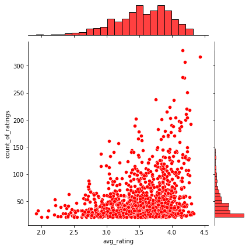

```python
#visualize the average rating with count of ratings using jointplot
sns.jointplot(x='avg_rating',y='count_of_ratings', data=df_movie_ratings_final, color='red')
```

- The average rating can be seen around 3.5 to 4
- And most of the movies have the count of ratings less than 150
- We can see that popular movies tend to have maximum rating count and are high than average rating

```python
#merge with movie title, userId and movieId
df_movie_ratings = pd.merge(df_ratings,df_movie_ratings_final,on='title',how='inner')
```

```python
df_movie_ratings.head()
```

|  | userId | movieId | rating | timestamp | title | genres | avg_rating | count_of_ratings |
| --- | --- | --- | --- | --- | --- | --- | --- | --- |
| 0 | 1 | 1 | 4.0 | 2000-07-30 18:45:03 | Toy Story (1995) | Adventure\|Animation\|Children\|Comedy\|Fantasy | 3.92093 | 215 |
| 1 | 5 | 1 | 4.0 | 1996-11-08 06:36:02 | Toy Story (1995) | Adventure\|Animation\|Children\|Comedy\|Fantasy | 3.92093 | 215 |
| 2 | 7 | 1 | 4.5 | 2005-01-25 06:52:26 | Toy Story (1995) | Adventure\|Animation\|Children\|Comedy\|Fantasy | 3.92093 | 215 |
| 3 | 15 | 1 | 2.5 | 2017-11-13 12:59:30 | Toy Story (1995) | Adventure\|Animation\|Children\|Comedy\|Fantasy | 3.92093 | 215 |
| 4 | 17 | 1 | 4.5 | 2011-05-18 05:28:03 | Toy Story (1995) | Adventure\|Animation\|Children\|Comedy\|Fantasy | 3.92093 | 215 |

```python
print( "The ratings dataset has" ,df_movie_ratings['userId'].nunique(), 'unique users')
print( "The ratings dataset has" ,df_movie_ratings['title'].nunique(), 'unique movies')
print( "The ratings dataset has" ,df_movie_ratings['rating'].nunique(), 'unique ratings')
```

```
The ratings dataset has 610 unique users
The ratings dataset has 1235 unique movies
The ratings dataset has 10 unique ratings
```

## Creating User - Movie matrix

We have created a matrix for the unique set of users in rows and movies in columns with values as ratings. When the movie is rated by that particular user it contains the specific rating as value and if not rated it shows 'NaN

```python
# pivot ratings into movie features
user_movie_matrix = df_movie_ratings.pivot_table(
    index='userId',
    columns='title',
    values='rating'
)
user_movie_matrix.head()
```

| title userId | (500) Days of Summer (2009) | 10 Things I Hate About You (1999) | 101 Dalmatians (1996) | 101 Dalmatians (One Hundred and One Dalmatians) (1961) | 12 Angry Men (1957) | 13 Going on 30 (2004) | 13th Warrior, The (1999) | 1408 (2007) | 2001: A Space Odyssey (1968) | 2012 (2009) | ... | Young Frankenstein (1974) | Young Guns (1988) | Zack and Miri Make a Porno (2008) | Zodiac (2007) | Zombieland (2009) | Zoolander (2001) | Zootopia (2016) | eXistenZ (1999) | xXx (2002) | ¡Three Amigos! (1986) |
| --- | --- | --- | --- | --- | --- | --- | --- | --- | --- | --- | --- | --- | --- | --- | --- | --- | --- | --- | --- | --- | --- |
| 1 | NaN | NaN | NaN | NaN | NaN | NaN | 4.0 | NaN | NaN | NaN | ... | 5.0 | NaN | NaN | NaN | NaN | NaN | NaN | NaN | NaN | 4.0 |
| 2 | NaN | NaN | NaN | NaN | NaN | NaN | NaN | NaN | NaN | NaN | ... | NaN | NaN | NaN | NaN | 3.0 | NaN | NaN | NaN | NaN | NaN |
| 3 | NaN | NaN | NaN | NaN | NaN | NaN | NaN | NaN | NaN | 0.5 | ... | NaN | NaN | NaN | NaN | NaN | NaN | NaN | NaN | NaN | NaN |
| 4 | NaN | NaN | NaN | NaN | 5.0 | NaN | NaN | NaN | NaN | NaN | ... | NaN | NaN | NaN | NaN | NaN | NaN | NaN | NaN | NaN | NaN |
| 5 | NaN | NaN | NaN | NaN | NaN | NaN | NaN | NaN | NaN | NaN | ... | NaN | NaN | NaN | NaN | NaN | NaN | NaN | NaN | NaN | NaN |

5 rows × 1235 columns

```python
user_movie_matrix.shape
```

```
(610, 1235)
```

We normalize the matrix by finding the average rating for each movies by the user and subtracting it with all the values. This is done to normalize the data as some of the users might have a different rating preferences.

```python
#Nomralize the user-movie matrix
user_movie_matrix_norm = user_movie_matrix.subtract(user_movie_matrix.mean(axis=1),axis='rows')
user_movie_matrix_norm.head()
```

| title userId | (500) Days of Summer (2009) | 10 Things I Hate About You (1999) | 101 Dalmatians (1996) | 101 Dalmatians (One Hundred and One Dalmatians) (1961) | 12 Angry Men (1957) | 13 Going on 30 (2004) | 13th Warrior, The (1999) | 1408 (2007) | 2001: A Space Odyssey (1968) | 2012 (2009) | ... | Young Frankenstein (1974) | Young Guns (1988) | Zack and Miri Make a Porno (2008) | Zodiac (2007) | Zombieland (2009) | Zoolander (2001) | Zootopia (2016) | eXistenZ (1999) | xXx (2002) | ¡Three Amigos! (1986) |
| --- | --- | --- | --- | --- | --- | --- | --- | --- | --- | --- | --- | --- | --- | --- | --- | --- | --- | --- | --- | --- | --- |
| 1 | NaN | NaN | NaN | NaN | NaN | NaN | -0.422222 | NaN | NaN | NaN | ... | 0.577778 | NaN | NaN | NaN | NaN | NaN | NaN | NaN | NaN | -0.422222 |
| 2 | NaN | NaN | NaN | NaN | NaN | NaN | NaN | NaN | NaN | NaN | ... | NaN | NaN | NaN | NaN | -0.934783 | NaN | NaN | NaN | NaN | NaN |
| 3 | NaN | NaN | NaN | NaN | NaN | NaN | NaN | NaN | NaN | -1.068182 | ... | NaN | NaN | NaN | NaN | NaN | NaN | NaN | NaN | NaN | NaN |
| 4 | NaN | NaN | NaN | NaN | 1.455882 | NaN | NaN | NaN | NaN | NaN | ... | NaN | NaN | NaN | NaN | NaN | NaN | NaN | NaN | NaN | NaN |
| 5 | NaN | NaN | NaN | NaN | NaN | NaN | NaN | NaN | NaN | NaN | ... | NaN | NaN | NaN | NaN | NaN | NaN | NaN | NaN | NaN | NaN |

5 rows × 1235 columns

The negative values represents the rating lesser than user's average rating and the positive value represents the movies with a rating more than user's average rating

## Find out similar users

Calculating similarity score for the matrix values. Here, Pearson correlation has been used. It is not required to replace missing values with 0 is this calculation

```python
matrix = user_movie_matrix_norm.T.corr()
```

```python
matrix.head()
```

| userId | 1 | 2 | 3 | 4 | 5 | 6 | 7 | 8 | 9 | 10 | ... | 601 | 602 | 603 | 604 | 605 | 606 | 607 | 608 | 609 | 610 |
| --- | --- | --- | --- | --- | --- | --- | --- | --- | --- | --- | --- | --- | --- | --- | --- | --- | --- | --- | --- | --- | --- |
| 1 | 1.000000 | NaN | 0.166091 | 0.207983 | 0.268749 | -0.291636 | -0.118773 | 0.469668 | 0.918559 | -0.037987 | ... | 0.091574 | -1.183502e-17 | -0.050843 | -0.407556 | -0.195628 | 0.073490 | 0.087659 | 0.230418 | -0.175412 | -0.056271 |
| 2 | NaN | 1.0 | NaN | NaN | NaN | NaN | -0.991241 | NaN | NaN | 0.037796 | ... | -0.387347 | NaN | -1.000000 | NaN | NaN | 0.583333 | NaN | -0.125000 | NaN | 0.623288 |
| 3 | 0.166091 | NaN | 1.000000 | NaN | NaN | NaN | NaN | NaN | NaN | NaN | ... | NaN | NaN | 0.414644 | NaN | NaN | -0.842914 | -0.333333 | -0.395092 | NaN | 0.460806 |
| 4 | 0.207983 | NaN | NaN | 1.000000 | -0.345099 | 0.175709 | 0.542861 | 0.117851 | NaN | 0.485794 | ... | -0.222113 | 4.256844e-01 | 0.060471 | -0.080296 | 0.461163 | 0.121749 | 0.116518 | -0.183175 | NaN | 0.012919 |
| 5 | 0.268749 | NaN | NaN | -0.345099 | 1.000000 | 0.043166 | 0.158114 | 0.028347 | NaN | -0.777714 | ... | 0.000000 | 2.160186e-01 | 0.214784 | 0.067791 | -0.364156 | 0.252706 | 0.231080 | -0.020546 | 0.384111 | 0.040582 |

5 rows × 610 columns

Using a particular user id as example to illustrate on how to find similar users. Excluding user Id 1 from the user list and decide the number of similar users

```python
#Picking a userid
user = 1
#Remove the above userId from matrix list
matrix.drop(index=user, inplace=True)
matrix.head()
```

| userId | 1 | 2 | 3 | 4 | 5 | 6 | 7 | 8 | 9 | 10 | ... | 601 | 602 | 603 | 604 | 605 | 606 | 607 | 608 | 609 | 610 |
| --- | --- | --- | --- | --- | --- | --- | --- | --- | --- | --- | --- | --- | --- | --- | --- | --- | --- | --- | --- | --- | --- |
| 2 | NaN | 1.0 | NaN | NaN | NaN | NaN | -0.991241 | NaN | NaN | 0.037796 | ... | -0.387347 | NaN | -1.000000 | NaN | NaN | 0.583333 | NaN | -0.125000 | NaN | 0.623288 |
| 3 | 0.166091 | NaN | 1.0 | NaN | NaN | NaN | NaN | NaN | NaN | NaN | ... | NaN | NaN | 0.414644 | NaN | NaN | -0.842914 | -0.333333 | -0.395092 | NaN | 0.460806 |
| 4 | 0.207983 | NaN | NaN | 1.000000 | -0.345099 | 0.175709 | 0.542861 | 0.117851 | NaN | 0.485794 | ... | -0.222113 | 0.425684 | 0.060471 | -0.080296 | 0.461163 | 0.121749 | 0.116518 | -0.183175 | NaN | 0.012919 |
| 5 | 0.268749 | NaN | NaN | -0.345099 | 1.000000 | 0.043166 | 0.158114 | 0.028347 | NaN | -0.777714 | ... | 0.000000 | 0.216019 | 0.214784 | 0.067791 | -0.364156 | 0.252706 | 0.231080 | -0.020546 | 0.384111 | 0.040582 |
| 6 | -0.291636 | NaN | NaN | 0.175709 | 0.043166 | 1.000000 | -0.126595 | -0.200062 | NaN | 0.957427 | ... | -0.292770 | -0.039592 | -0.132017 | -0.101668 | 0.134307 | -0.180119 | 0.427674 | 0.038531 | 0.193649 | 0.014001 |

5 rows × 610 columns

- In the above matrix the values range from -1 to 1, where -1 represents dissimilar user preferences and 1 represents most similar users
- Let n be the number of similar users based on a userid. And the threshold to be set as high as possible to narrow down the most similar users.
- For example the threshold set to 0.8 implies that the pearson correlation should be above 0.8 for a user to be identified as similar users

```python
#Similar users to get
n = 10

#set threshold to find most similar users
threshold = 0.8

#Get n similar users
similar_users = matrix[matrix[user] > threshold][user].sort_values(ascending=False)[:n]

print(f'The n similar users for userid {user} are below', similar_users)
```

```
The n similar users for userid 1 are below userId
106    1.000000
333    1.000000
481    1.000000
499    1.000000
550    1.000000
598    1.000000
511    0.925820
9      0.918559
13     0.878310
366    0.872872
Name: 1, dtype: float64
```

## Get the watched list for target users

We can narrow the similarity by identifying the watched list of a user and remove them from the recommendation step.

To remove the movies watched by the target user, we keep only the row for userId=1 in the matrix and remove the items with missing values.

```python
# Movies that the target user has watched
user_watched_list = user_movie_matrix_norm[user_movie_matrix_norm.index == user].dropna(axis=1, how='all')
user_watched_list
```

| title userId | 13th Warrior, The (1999) | Abyss, The (1989) | Alice in Wonderland (1951) | Alien (1979) | American Beauty (1999) | American History X (1998) | Apocalypse Now (1979) | Austin Powers: International Man of Mystery (1997) | Back to the Future (1985) | Back to the Future Part III (1990) | ... | Wedding Singer, The (1998) | What About Bob? (1991) | Who Framed Roger Rabbit? (1988) | Wild Things (1998) | Willow (1988) | Willy Wonka & the Chocolate Factory (1971) | Wizard of Oz, The (1939) | X-Men (2000) | Young Frankenstein (1974) | ¡Three Amigos! (1986) |
| --- | --- | --- | --- | --- | --- | --- | --- | --- | --- | --- | --- | --- | --- | --- | --- | --- | --- | --- | --- | --- | --- |
| 1 | -0.422222 | -0.422222 | 0.577778 | -0.422222 | 0.577778 | 0.577778 | -0.422222 | 0.577778 | 0.577778 | -0.422222 | ... | -0.422222 | -0.422222 | 0.577778 | -0.422222 | -0.422222 | 0.577778 | 0.577778 | 0.577778 | 0.577778 | -0.422222 |

1 rows × 180 columns

To keep only the similar users’ movies, keeping the user IDs in the top 10 similar user lists and remove the matrix with all missing values. All missing value for a movie means that none of the similar users have watched the movie.

```python
# Movies that similar users watched. Remove movies that none of the similar users have watched
similar_user_movies = user_movie_matrix_norm[user_movie_matrix_norm.index.isin(similar_users.index)].dropna(axis=1, how='all')
similar_user_movies
```

| title userId | 1408 (2007) | 2001: A Space Odyssey (1968) | 21 Jump Street (2012) | Adaptation (2002) | Air Force One (1997) | Alien: Resurrection (1997) | Almost Famous (2000) | Amadeus (1984) | Amelie (Fabuleux destin d'Amélie Poulain, Le) (2001) | Arrival (2016) | ... | Toy Story (1995) | Up (2009) | V for Vendetta (2006) | WALL·E (2008) | What Lies Beneath (2000) | What's Eating Gilbert Grape (1993) | Witness (1985) | Wolf of Wall Street, The (2013) | X-Men (2000) | xXx (2002) |
| --- | --- | --- | --- | --- | --- | --- | --- | --- | --- | --- | --- | --- | --- | --- | --- | --- | --- | --- | --- | --- | --- |
| 9 | NaN | NaN | NaN | 1.090909 | NaN | NaN | NaN | NaN | NaN | NaN | ... | NaN | NaN | NaN | NaN | NaN | NaN | 0.090909 | NaN | NaN | -2.909091 |
| 13 | NaN | NaN | NaN | NaN | NaN | NaN | 0.12 | NaN | NaN | NaN | ... | NaN | NaN | NaN | NaN | 0.12 | NaN | NaN | NaN | 0.12 | NaN |
| 106 | NaN | NaN | NaN | NaN | NaN | NaN | NaN | NaN | NaN | NaN | ... | NaN | NaN | NaN | NaN | NaN | NaN | NaN | NaN | NaN | NaN |
| 333 | NaN | -0.714286 | NaN | NaN | NaN | NaN | NaN | NaN | NaN | NaN | ... | NaN | NaN | NaN | NaN | NaN | 0.285714 | NaN | NaN | NaN | NaN |
| 366 | NaN | NaN | NaN | NaN | NaN | NaN | NaN | NaN | NaN | NaN | ... | NaN | NaN | -0.451613 | NaN | NaN | NaN | NaN | NaN | NaN | NaN |
| 481 | NaN | NaN | NaN | NaN | 0.941176 | -1.058824 | NaN | NaN | NaN | NaN | ... | NaN | NaN | NaN | NaN | NaN | NaN | NaN | NaN | NaN | NaN |
| 499 | NaN | NaN | NaN | NaN | NaN | NaN | NaN | 1.0 | NaN | NaN | ... | NaN | NaN | NaN | NaN | NaN | NaN | NaN | NaN | NaN | NaN |
| 511 | -0.818182 | NaN | NaN | NaN | NaN | NaN | NaN | NaN | -0.318182 | -0.318182 | ... | NaN | 0.181818 | NaN | NaN | NaN | NaN | NaN | NaN | NaN | NaN |
| 550 | NaN | NaN | -0.288462 | NaN | NaN | NaN | NaN | NaN | NaN | NaN | ... | -0.288462 | 0.211538 | NaN | -0.288462 | NaN | NaN | NaN | -0.288462 | NaN | NaN |
| 598 | NaN | NaN | NaN | NaN | NaN | NaN | NaN | NaN | NaN | NaN | ... | NaN | NaN | NaN | NaN | NaN | NaN | NaN | NaN | NaN | NaN |

10 rows × 177 columns

The above matrix has index with all 10 similar users to userid = 1 and their watched movie list. From this list we need to drop the movies watched by userid 1.

```python
# Remove the watched movie from the movie list
similar_user_movies.drop(user_watched_list.columns,axis=1, inplace=True, errors='ignore') #errors='ignore' drops columns if they exist without giving an error message.

# Take a look at the data
similar_user_movies
```

| title userId | 1408 (2007) | 2001: A Space Odyssey (1968) | 21 Jump Street (2012) | Adaptation (2002) | Air Force One (1997) | Alien: Resurrection (1997) | Almost Famous (2000) | Amadeus (1984) | Amelie (Fabuleux destin d'Amélie Poulain, Le) (2001) | Arrival (2016) | ... | Thor (2011) | Titanic (1997) | Up (2009) | V for Vendetta (2006) | WALL·E (2008) | What Lies Beneath (2000) | What's Eating Gilbert Grape (1993) | Witness (1985) | Wolf of Wall Street, The (2013) | xXx (2002) |
| --- | --- | --- | --- | --- | --- | --- | --- | --- | --- | --- | --- | --- | --- | --- | --- | --- | --- | --- | --- | --- | --- |
| 9 | NaN | NaN | NaN | 1.090909 | NaN | NaN | NaN | NaN | NaN | NaN | ... | NaN | NaN | NaN | NaN | NaN | NaN | NaN | 0.090909 | NaN | -2.909091 |
| 13 | NaN | NaN | NaN | NaN | NaN | NaN | 0.12 | NaN | NaN | NaN | ... | NaN | 0.120000 | NaN | NaN | NaN | 0.12 | NaN | NaN | NaN | NaN |
| 106 | NaN | NaN | NaN | NaN | NaN | NaN | NaN | NaN | NaN | NaN | ... | -0.500000 | NaN | NaN | NaN | NaN | NaN | NaN | NaN | NaN | NaN |
| 333 | NaN | -0.714286 | NaN | NaN | NaN | NaN | NaN | NaN | NaN | NaN | ... | NaN | NaN | NaN | NaN | NaN | NaN | 0.285714 | NaN | NaN | NaN |
| 366 | NaN | NaN | NaN | NaN | NaN | NaN | NaN | NaN | NaN | NaN | ... | NaN | NaN | NaN | -0.451613 | NaN | NaN | NaN | NaN | NaN | NaN |
| 481 | NaN | NaN | NaN | NaN | 0.941176 | -1.058824 | NaN | NaN | NaN | NaN | ... | NaN | 1.941176 | NaN | NaN | NaN | NaN | NaN | NaN | NaN | NaN |
| 499 | NaN | NaN | NaN | NaN | NaN | NaN | NaN | 1.0 | NaN | NaN | ... | NaN | NaN | NaN | NaN | NaN | NaN | NaN | NaN | NaN | NaN |
| 511 | -0.818182 | NaN | NaN | NaN | NaN | NaN | NaN | NaN | -0.318182 | -0.318182 | ... | NaN | NaN | 0.181818 | NaN | NaN | NaN | NaN | NaN | NaN | NaN |
| 550 | NaN | NaN | -0.288462 | NaN | NaN | NaN | NaN | NaN | NaN | NaN | ... | -0.288462 | NaN | 0.211538 | NaN | -0.288462 | NaN | NaN | NaN | -0.288462 | NaN |
| 598 | NaN | NaN | NaN | NaN | NaN | NaN | NaN | NaN | NaN | NaN | ... | NaN | NaN | NaN | NaN | NaN | NaN | NaN | NaN | NaN | NaN |

10 rows × 151 columns